# Homework 3 - Divij Sanjanwala

```r
## R packages
setwd(getwd())
library(SpatialEpi)
library(tidyverse)
library(sf)
library(spdep)
library(rmarkdown)
library(INLA)
library(tmap) ## Very commonly used -- to make static and interactive plots
library(mapview)
library(cowplot)
library(reshape2)
library(leaflet)
library(raster)
library(shiny)
library(MASS)
library(tidyverse)
library(spDataLarge) ## Data sets -- use commands in notes to download
library(spData) ## Data sets
library(sf) ## simple features
```

## Question 1.1: Define a Gaussian Markov random field and describe construction of the precision matrix.

To understand the Gaussian Markov random field, we can break down the definition into 3 parts: Gaussian, Markov, and Random Field.

1. Markov:
- A Stochastic process that is a collection of random variables whose typically characterized by a probability distribution that describes the likelihood of observing different outcomes at different times.
- Thus, a Markov Property defines that the future state of a stochastic process depends only an only on its present state, and not on its past states.
2. Random Field: are mathematical models that are a collection of random variables, where each random variable is associated to a specific point in time/space.
3. Gaussian: refers to the Gaussian (Normal) distribution where points are defined under a bell shaped curve. A Gaussian random variable is one that follows the Gaussian/Normal Distribution whose points in space are generally centered around the mean and 68% of the points in space are 1 standard deviation away from the mean.

Finally, Gaussian Markov Random Field: refers to a random field whose points in space follows a Normal/Gaussian Distribution and have dependence only on the previous ie: neighbor points in space. For a temporal model, Gaussian Markov Random Field points are defined in a Gaussian Distribution, with a point in the future of t, is dependent only on the previous time state ie: t - 1 and not t - 2 etc.

We have a better mathematical definition here:

Let $\mathcal{N}_i$ be neighborhood of points $x_i$ s.t $x_j, j \in \mathcal{N_i}$ are defined by a neighborhood function (e.g. returns the point $j$ s.t $j \neq i$ and is minimum Euclidean distance of all points in the space)

A Gaussian Markov Random Field is defined as:

$p\left(x_i \mid\left\{x_j: j \neq i\right\}\right)=p\left(x_i \mid\left\{x_j: j \in \mathcal{N}_i\right\}\right)$

Here, $j \in \mathcal{N_i}$ satisfies the Markov Property given a Neighborhood Function, and the probability of $x_i$ depends only on the neighboring points $x_j$ and not beyond that.

The Precision Matrix: a matrix used to define the Markovian Structure of the Gaussian Markov Random Field, where each entry defines the dependence of the neighboring points in space. This is similar to an adjacency matrix used to define a finite graph ($W_{ij} = 1$ to define an edge and $W_{ij} = 0$ to define no edge). Relevant transformations for instance that define the strength of the Markovian property are applied.

## Question 1.2: Define a Gaussian random field and describe construction of the covariance matrix.

Referring to the definition breakdown in Question 1.1L

Gaussian Random Field: is defined as a random field, i.e. a field where random variables are points in space, where the points in space are Normally Distributed.

Given a covariance matrix $W$ and a space $S$.

For all the points $i, j \in S$, we calculate the covariance $C_{ij}$ and define it under the entry $W_{ij}$.

## Question 1.3: Compare and contrast a Gaussian Markov random field and a Gaussian random field. What similarities do they share and how do they differ?

Both Gaussian Markov Random Fields and Gaussian Randoms Fields have points defined as random variables i.e. each point is a random variable in space. These points in space also belong to the Gaussian Distribution, although the dependence structure of the points in both the fields differ.

In a Gaussian Markov Random Field (GMRF), points in space follow the Markovian Property. This means, the points in space are dependent on the points in the neighborhood i.e. a certain point $x_i$ has it’s probability dependent on the $x_j$ s.t. $x_j \in \mathcal{N_i}$ although are still identically distributed due the the Gaussian Property. However, the points in the Gaussian Random Fields (GRF) do not follow this property, and points in space are independently and identically distributed. Hence, points in GRF are i.i.d although points in GMRF are only identically distributed, and have the probability in space dependent on their Neighborhoods.

## Question 2:

```r
## load in the R packages needed and data
library(geoR)
library(sf)
library(tidyverse)
library(sp)
library(rgdal)
library(tmap)
library(raster)
library(geodist)
library(INLA)
library(rSPDE)
library(xtable)
library(MASS)
data(gambia)
## aggregate by location and convert the object into a 'sf' object

d <- group_by(gambia, x, y) %>%
  summarize(total = n(),
            positive = sum(pos),
            prev = positive / total)

sps <- SpatialPoints(d[, c("x", "y")],
                     proj4string = CRS("+proj=utm +zone=28"))

spst <- spTransform(sps, CRS("+proj=longlat +datum=WGS84"))

d[,c("long", "lat")] <- spst@coords

r <- getData(name = "alt", country = "GMB", mask = TRUE)

d$alt <- raster::extract(r, d[, c("long", "lat")])

gambia.sf <- st_as_sf(d, coords = c("long", "lat"), crs = "+proj=longlat +datum=WGS84")

gambia.six <- gambia.sf[1:6,]

## map of the prevalence data
tmap_mode("view")
tm_shape(gambia.sf) + tm_dots("prev", title = "Prevalence")
```

[interactive chart not shown]

## Question 2.1: What is the geometry type and CRS of the The Gambia data set, gambia.sf? Display total and prevalence in a two panel plot.

```r
gambia.sf
```

```
## Simple feature collection with 65 features and 6 fields
## Geometry type: POINT
## Dimension:     XY
## Bounding box:  xmin: -16.38755 ymin: 13.18541 xmax: -13.87273 ymax: 13.66438
## CRS:           +proj=longlat +datum=WGS84
## # A tibble: 65 × 7
## # Groups:   x [65]
##          x       y total positive  prev   alt             geometry
##  *   <dbl>   <dbl> <int>    <dbl> <dbl> <dbl>          <POINT [°]>
##  1 349631. 1458055    33       17 0.515    14 (-16.38755 13.18541)
##  2 358543. 1460112    63       19 0.302    30 (-16.30543 13.20444)
##  3 360308. 1460026    17        7 0.412    32 (-16.28914 13.20374)
##  4 363796. 1496919    24        8 0.333    20 (-16.25869 13.53742)
##  5 366400. 1460248    26       10 0.385    28 (-16.23294 13.20603)
##  6 366688. 1463002    18        7 0.389    17 (-16.23041 13.23094)
##  7 368420. 1460569    38       24 0.632    12 (-16.21431 13.20902)
##  8 370400. 1460301    56        7 0.125    29 (-16.19604 13.20668)
##  9 370628. 1499589    57        6 0.105    38 (-16.19569 13.56187)
## 10 374403. 1501392    26        8 0.308    37 (-16.16088 13.57834)
## # … with 55 more rows
```

The CRS: `+proj=longlat +datum=WGS84` `Geometry type: POINT`

```r
## map of the prevalence data
tmap_mode("view")
tm_shape(gambia.sf) +
  tm_dots(c("prev", "total"), title=c("Prevalence", "Total")) +
  tm_facets(sync = TRUE, nrow = 1, ncol = 2)
```

[interactive chart not shown]

## Question 2.2:

We will fit a model to the prevalence data of The Gambia, but first simulate from the prior predictive distribution. For the covariance matrix we’ll need to compute the distance matrix

```r
dist.matrix <- geodist(d[,c("long", "lat")], measure = "geodesic")
```

Assuming a Matérn covariance matrix structure, use the following prior distributions to simulate 100 data sets from the prior predictive distribution:

$\beta_0 \sim N(0,1), \beta_1 \sim N(0,1), \kappa \sim \operatorname{Gamma}(\text{shape}=0.1, \text{rate}=1), \nu \sim \operatorname{Gamma}(10,1), \sigma \operatorname{Gamma}(1,1)$

```r
# Some example code

sim_data <- array(0, dim = c(65, 65, 100))
# A Covariance matrix of dim(65 x 65) yields mvr data of dim(1 x 65):
# Hence, for 100 simulations Covariance matrix => (65, 65, 100) and MVR => (65 x 100)
mvr.data <- array(0, dim = c(65, 100))
logit.p_s <- array(0, dim = c(65, 100))
# Similarly the prediction will have the same dim as the MVR data.
p_s.prediction <- array(0, dim = c(65, 100))

beta0.pr1 <- rnorm(n=65, mean=0, sd=1)
beta1.pr1 <- rnorm(n=65, mean=0, sd=1)

for (i in 1:100) {
  beta0 <- rnorm(1, mean = 0, sd = 1)
  beta1 <- rnorm(1, mean = 0, sd = 1)
  kappa <- rgamma(1, shape = 0.1, rate = 1)
  nu <- rgamma(1, shape = 10, rate = 1)
  sigma <- rgamma(1, shape = 1, rate = 1)

  sim_data[,,i] <- rSPDE::matern.covariance(h = dist.matrix, kappa = kappa, nu = nu, sigma = sigma)

  # Get the dimensions of the covariance matrix
  n <- dim(sim_data)[1]

  # Generate a sample of multivariate normal random variables for a zero-gaussian
  x <- mvrnorm(n = 1, mu = rep(0, n), Sigma = sim_data[,,i])

  mvr.data[,i] <- x

  ## Prediction using the logit function
  logit.p_s[,i] <- beta0.pr1 + beta1.pr1*matrix(gambia.sf$alt, nrow=1, ncol=65) + mvr.data[,i]
  p_s.prediction[, i] <- exp(logit.p_s[,i])
}
```

For the first six locations in `gambia.sf`, make a histogram of the prior predictive draws of prevalence, $P(s_i)$, and add a vertical line at the observed value.

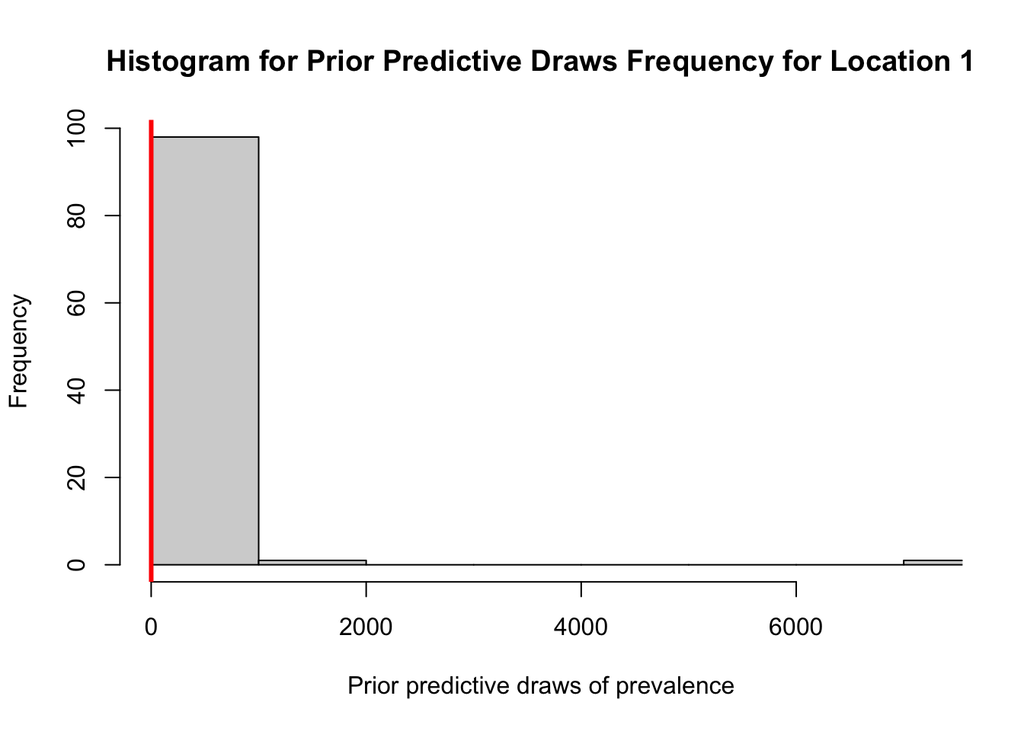

```r
max_val <- max(max(p_s.prediction[1,]), gambia.six$prev[1])

hist(p_s.prediction[1,],
     main="Histogram for Prior Predictive Draws Frequency for Location 1",
     xlab = "Prior predictive draws of prevalence",
     xlim=c(min(p_s.prediction[1,]), max_val))
      abline(v=gambia.six$prev[1], lwd=3, col="red")
```

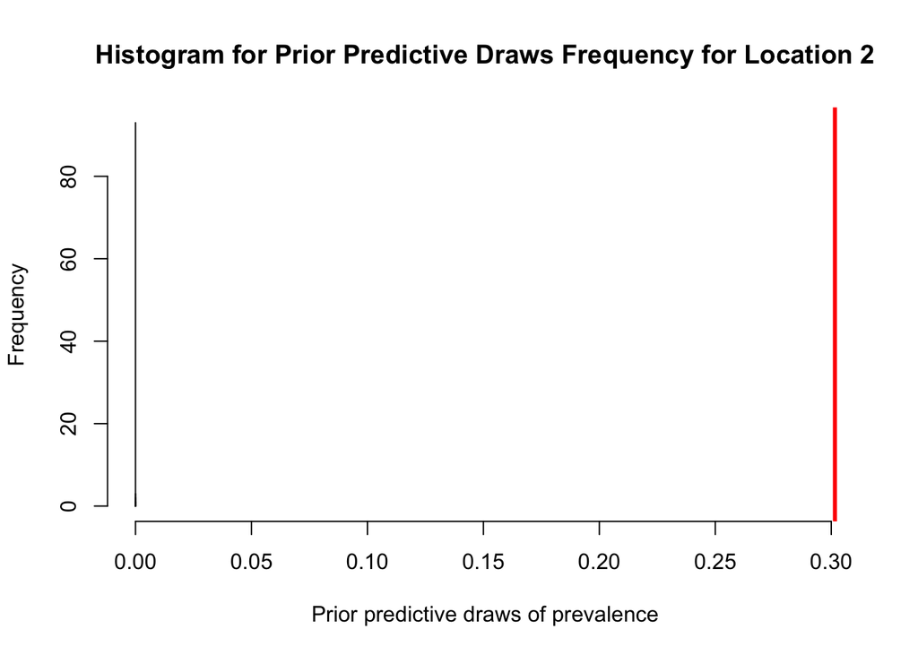

```r
max_val <- max(max(p_s.prediction[2,]), gambia.six$prev[2])

hist(p_s.prediction[2,],
     main="Histogram for Prior Predictive Draws Frequency for Location 2",
     xlab = "Prior predictive draws of prevalence",
     xlim=c(min(p_s.prediction[2,]), max_val))
     abline(v=gambia.six$prev[2], lwd=3, col="red")
```

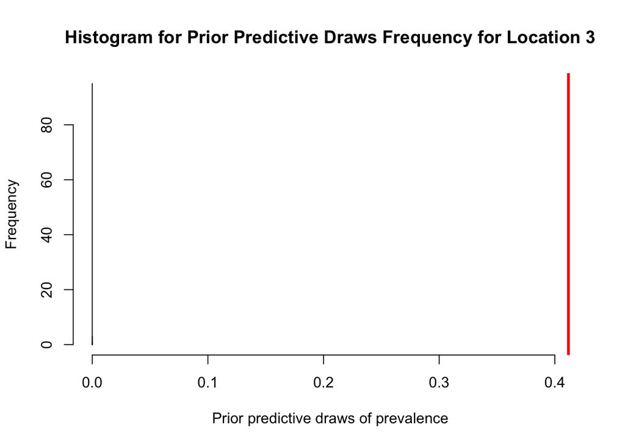

```r
max_val <- max(max(p_s.prediction[3,]), gambia.six$prev[3])

hist(p_s.prediction[3,],
     main="Histogram for Prior Predictive Draws Frequency for Location 3",
     xlab = "Prior predictive draws of prevalence",
     xlim=c(min(p_s.prediction[3,]), max_val))
      abline(v=gambia.six$prev[3], lwd=3, col="red")
```

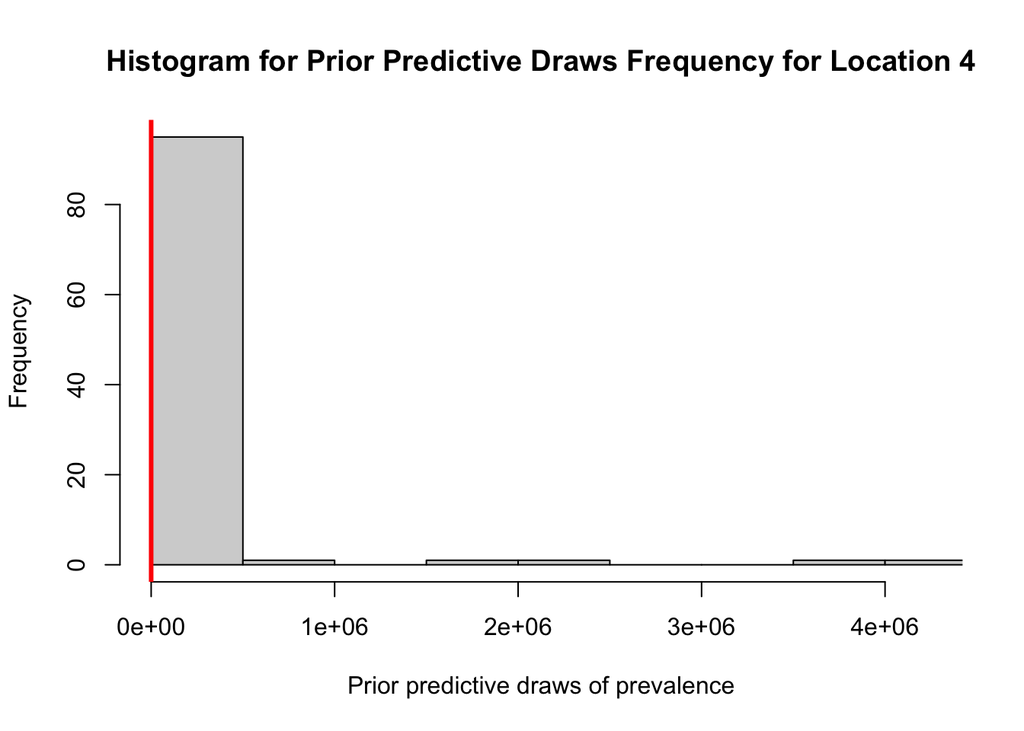

```r
max_val <- max(max(p_s.prediction[4,]), gambia.six$prev[4])

hist(p_s.prediction[4,],
     main="Histogram for Prior Predictive Draws Frequency for Location 4",
     xlab = "Prior predictive draws of prevalence",
     xlim=c(min(p_s.prediction[4,]), max_val))
      abline(v=gambia.six$prev[4], lwd=3, col="red")
```

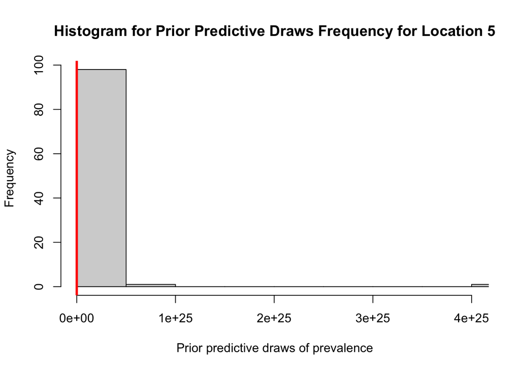

```r
max_val <- max(max(p_s.prediction[5,]), gambia.six$prev[5])

hist(p_s.prediction[5,],
     main="Histogram for Prior Predictive Draws Frequency for Location 5",
     xlab = "Prior predictive draws of prevalence",
     xlim=c(min(p_s.prediction[5,]), max_val))
      abline(v=gambia.six$prev[5], lwd=3, col="red")
```

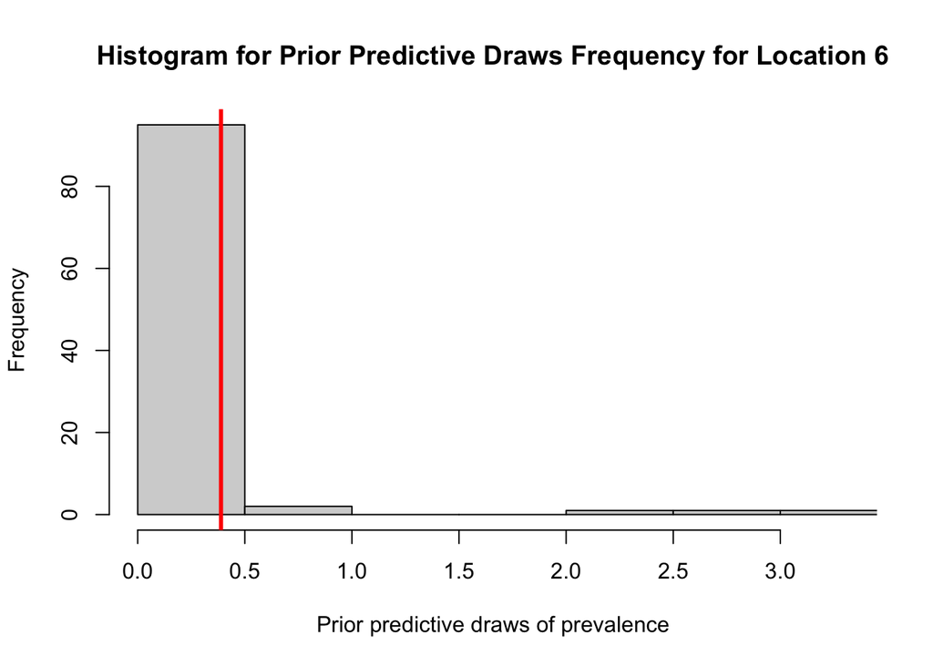

```r
max_val <- max(max(p_s.prediction[6,]), gambia.six$prev[6])

hist(p_s.prediction[6,],
     main="Histogram for Prior Predictive Draws Frequency for Location 6",
     xlab = "Prior predictive draws of prevalence",
     xlim=c(min(p_s.prediction[6,]), max_val))
      abline(v=gambia.six$prev[6], lwd=3, col="red")
```

# Question 2.4:

- Exponential
- Matérn using SPDE2
- Matérn with penalized complexity priors

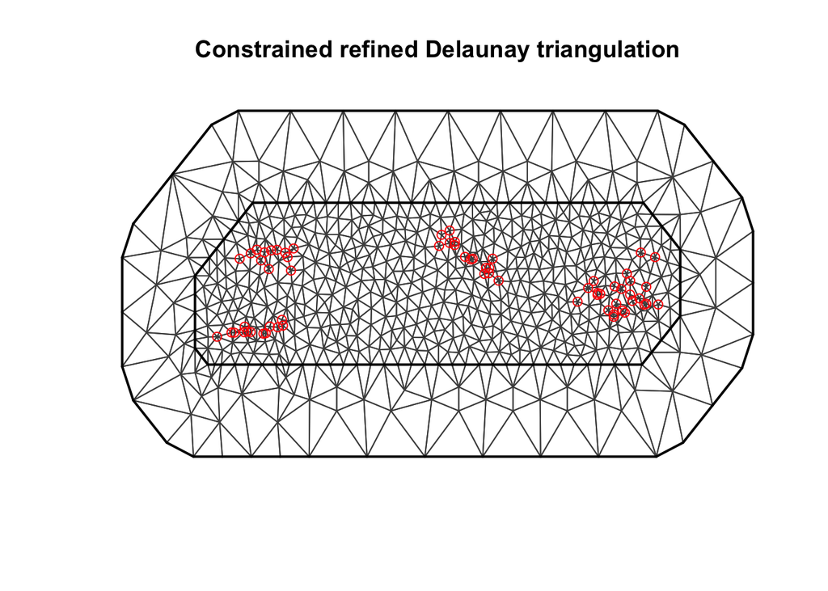

```r
# Mesh construction
coo <- cbind(d$long, d$lat)
mesh <- inla.mesh.2d(loc = coo, max.edge = c(0.1, 5), cutoff = 0.01)
plot(mesh)
points(coo, col = "red")
```

```r
# We'll change the spde depending on what we want to fit
#Exponential
spde.exponential <- inla.spde2.matern(mesh = mesh, alpha = 3/2, constr = TRUE)
# SPDE2 Matérn
spde.maternspde <- inla.spde2.matern(mesh = mesh, alpha = 2, constr = TRUE)
# SPDE2 Matérn with penalized complexity priors
spde.penalized.matern <- inla.spde2.pcmatern(mesh = mesh,
                            alpha = 2,
                            constr = TRUE,
                            prior.range = c(10, 0.9),
                            prior.sigma = c(1, 0.01))

indexs <- inla.spde.make.index("s", spde.exponential$n.spde)

A <- inla.spde.make.A(mesh = mesh, loc = coo)

## Prediction data
dp <- rasterToPoints(r)
ra <- aggregate(r, fact = 5, fun = mean)
dp <- rasterToPoints(ra)
coop <- dp[, c("x", "y")]
Ap <- inla.spde.make.A(mesh = mesh, loc = coop)

# stack for estimation stk.e
stk.e <- inla.stack(tag = "est",
                    data = list(y = d$positive, numtrials = d$total),
                    A = list(1, A),
                    effects = list(data.frame(b0 = 1, altitude = d$alt),
                                   s = indexs))

# stack for prediction stk.p
stk.p <- inla.stack(tag = "pred",
                    data = list(y = NA, numtrials = NA),
                    A = list(1, Ap),
                    effects = list(data.frame(b0 = 1, altitude = dp[, 3]), s = indexs))

# stk.full has stk.e and stk.p
stk.full <- inla.stack(stk.e, stk.p)

formula.exponential <- y ~ 0 + b0 + altitude + f(s, model = spde.exponential)
formula.maternspde <- y ~ 0 + b0 + altitude + f(s, model = spde.maternspde)
formula.penalized.matern <- y ~ 0 + b0 + altitude + f(s, model = spde.penalized.matern)

res.exponential <- inla(formula.exponential, family = "binomial",
            Ntrials = numtrials,
            control.family = list(link = "logit"),
            data = inla.stack.data(stk.full),
            control.predictor = list(compute = TRUE, link = 1, A = inla.stack.A(stk.full)),
            control.compute = list(config = TRUE, return.marginals.predictor = TRUE),
            control.inla = list(int.strategy = 'eb'))

res.maternspde <- inla(formula.maternspde, family = "binomial",
            Ntrials = numtrials,
            control.family = list(link = "logit"),
            data = inla.stack.data(stk.full),
            control.predictor = list(compute = TRUE, link = 1, A = inla.stack.A(stk.full)),
            control.compute = list(config = TRUE, return.marginals.predictor = TRUE),
            control.inla = list(int.strategy = 'eb'))

res.penalized.matern <- inla(formula.penalized.matern, family = "binomial",
            Ntrials = numtrials,
            control.family = list(link = "logit"),
            data = inla.stack.data(stk.full),
            control.predictor = list(compute = TRUE, link = 1, A = inla.stack.A(stk.full)),
            control.compute = list(config = TRUE, return.marginals.predictor = TRUE),
            control.inla = list(int.strategy = 'eb'))
```

```r
## Plotting the results -- run chunk

index <- inla.stack.index(stk.full, tag = "pred")$data

pred_mean <- res.maternspde$summary.fitted.values[index, "mean"]
pred_ll <- res.maternspde$summary.fitted.values[index, "0.025quant"]
pred_ul <- res.maternspde$summary.fitted.values[index, "0.975quant"]

# Add model names to each data frame
model1.predictors <- cbind(Model = "Exponential", res.exponential$summary.fixed[c("mean", "0.025quant", "0.975quant")])
model2.predictors <- cbind(Model = "Matern SPDE", res.maternspde$summary.fixed[c("mean", "0.025quant", "0.975quant")])
model3.predictors <- cbind(Model = "Penalized Matern", res.penalized.matern$summary.fixed[c("mean", "0.025quant", "0.975quant")])

model1.params <-cbind(Model = "Exponential", res.exponential$summary.hyperpar)
model2.params <- cbind(Model = "Matern SPDE", res.maternspde$summary.hyperpar)
model3.params <- cbind(Model = "Penalized Matern", res.penalized.matern$summary.hyperpar)

# Bind the rows and keep the model names
summary_table.predictors <- rbind(model1.predictors, model2.predictors, model3.predictors)
summary_table.params <- rbind(model1.params, model2.params, model3.params)

dpm <- rbind(
  data.frame(
    long = coop[, 1], lat = coop[, 2],
    value = pred_mean, variable = "pred_mean"
  ),
  data.frame(
    long = coop[, 1], lat = coop[, 2],
    value = pred_ll, variable = "pred_ll"
  ),
  data.frame(
    long = coop[, 1], lat = coop[, 2],
    value = pred_ul, variable = "pred_ul"
  )
)

# Convert summary_table to a LaTeX table
latex_table.predictors <- xtable(summary_table.predictors, caption = "Summary table of Predictors")
latex_table.params <- xtable(summary_table.params, caption = "Summary table of Params")

summary_table.params
```

```
##                          Model       mean         sd 0.025quant   0.5quant
## Theta1 for s       Exponential -2.1126593 0.17793708 -2.4601372 -2.1139998
## Theta2 for s       Exponential  2.2033769 0.39964669  1.3962670  2.2106788
## Theta1 for s1      Matern SPDE -4.0198001 0.29070767 -4.5858722 -4.0226409
## Theta2 for s1      Matern SPDE  2.6693784 0.36712741  1.9337603  2.6738727
## Range for s   Penalized Matern  0.2737007 0.08164694  0.1525353  0.2605108
## Stdev for s   Penalized Matern  1.1187598 0.19823041  0.7871489  1.0985275
##               0.975quant      mode
## Theta1 for s  -1.7584052 -2.119030
## Theta2 for s   2.9721867  2.238627
## Theta1 for s1 -3.4391374 -4.033363
## Theta2 for s1  3.3818001  2.690896
## Range for s    0.4707578  0.235350
## Stdev for s    1.5654397  1.055596
```

```r
summary_table.predictors
```

```
##                      Model        mean  0.025quant  0.975quant
## b0             Exponential -0.31030794 -1.02482534 0.404209453
## altitude       Exponential -0.01000442 -0.03006571 0.010056870
## b01            Matern SPDE -0.25266082 -0.96961694 0.464295298
## altitude1      Matern SPDE -0.01148081 -0.03102976 0.008068141
## b02       Penalized Matern -0.15975666 -0.90123169 0.581718379
## altitude2 Penalized Matern -0.01257839 -0.03015035 0.004993576
```